# Исследование объявлений о продаже квартир

В вашем распоряжении данные сервиса Яндекc Недвижимость — архив объявлений о продаже квартир в Санкт-Петербурге и соседних населённых пунктах за несколько лет. Нужно научиться определять рыночную стоимость объектов недвижимости. Ваша задача — установить параметры. Это позволит построить автоматизированную систему: она отследит аномалии и мошенническую деятельность.

По каждой квартире на продажу доступны два вида данных. Первые вписаны пользователем, вторые получены автоматически на основе картографических данных. Например, расстояние до центра, аэропорта, ближайшего парка и водоёма.

**Цель исследования** — Научится определять рыночную стоимость недвижимости.

**Входные данный** - данные сервиса Яндекс Недвижимость — архив объявлений о продаже квартир в Санкт-Петербурге и соседних населённых пунктах за несколько лет. `real_estate_data.csv`

**Ход исследования**

1. **Обзор данных.** Мы проведем загрузку и обзор предоставленных данных.
2. **Предобработка данных.** Проверим данные на ошибки и пропуски, поищем возможность исправить самые критические ошибки. Оценив их влияние на исследования.
3. **Просчет и добавление данных.** Расчитаем и добавим в таблицу: цену за кв.м., день недели, месяц, год, группу этажности, соотношение жилой и общей и отношение кухни и общей площади.
4. **Анализ данных** Изучим и узнаем какие факторы влияют на стоимоть недвижимости.
5. **Вывод** Напишем общий вывод.

## Изучение данных из файла

### Для загрузки и обработки данных мы воспльзуемся библеотекой `pandas`

Дополнительно импортируем библиотеку `matplotlib` для работы с минимальным и максимальным желаемые значения для графиков.

А так же для работой с датой библиотеку `datetime`

```python
import pandas as pd #библиотеку pandas
import matplotlib.pyplot as plt #библиотеку matplotlib
from datetime import datetime as dt #библиотеку datetime
```

### Загрузим файл real_estate_data.csv из папки /datasets и сохраним в переменной df

И выведем первые 10 строк таблицы:

(посмотрев предварительно данные добавляем разделитель `\t`)

```python
try:
    df = pd.read_csv('/datasets/real_estate_data.csv', sep='\t')
    display('Загрузка онлайн')
except:
    df = pd.read_csv('real_estate_data.csv', sep='\t')
    display('Загрузка офлайн')

df.head(10)
```

```
'Загрузка офлайн'
```

|  | total_images | last_price | total_area | first_day_exposition | rooms | ceiling_height | floors_total | living_area | floor | is_apartment | ... | kitchen_area | balcony | locality_name | airports_nearest | cityCenters_nearest | parks_around3000 | parks_nearest | ponds_around3000 | ponds_nearest | days_exposition |
| --- | --- | --- | --- | --- | --- | --- | --- | --- | --- | --- | --- | --- | --- | --- | --- | --- | --- | --- | --- | --- | --- |
| 0 | 20 | 13000000.0 | 108.00 | 2019-03-07T00:00:00 | 3 | 2.70 | 16.0 | 51.00 | 8 | NaN | ... | 25.00 | NaN | Санкт-Петербург | 18863.0 | 16028.0 | 1.0 | 482.0 | 2.0 | 755.0 | NaN |
| 1 | 7 | 3350000.0 | 40.40 | 2018-12-04T00:00:00 | 1 | NaN | 11.0 | 18.60 | 1 | NaN | ... | 11.00 | 2.0 | посёлок Шушары | 12817.0 | 18603.0 | 0.0 | NaN | 0.0 | NaN | 81.0 |
| 2 | 10 | 5196000.0 | 56.00 | 2015-08-20T00:00:00 | 2 | NaN | 5.0 | 34.30 | 4 | NaN | ... | 8.30 | 0.0 | Санкт-Петербург | 21741.0 | 13933.0 | 1.0 | 90.0 | 2.0 | 574.0 | 558.0 |
| 3 | 0 | 64900000.0 | 159.00 | 2015-07-24T00:00:00 | 3 | NaN | 14.0 | NaN | 9 | NaN | ... | NaN | 0.0 | Санкт-Петербург | 28098.0 | 6800.0 | 2.0 | 84.0 | 3.0 | 234.0 | 424.0 |
| 4 | 2 | 10000000.0 | 100.00 | 2018-06-19T00:00:00 | 2 | 3.03 | 14.0 | 32.00 | 13 | NaN | ... | 41.00 | NaN | Санкт-Петербург | 31856.0 | 8098.0 | 2.0 | 112.0 | 1.0 | 48.0 | 121.0 |
| 5 | 10 | 2890000.0 | 30.40 | 2018-09-10T00:00:00 | 1 | NaN | 12.0 | 14.40 | 5 | NaN | ... | 9.10 | NaN | городской посёлок Янино-1 | NaN | NaN | NaN | NaN | NaN | NaN | 55.0 |
| 6 | 6 | 3700000.0 | 37.30 | 2017-11-02T00:00:00 | 1 | NaN | 26.0 | 10.60 | 6 | NaN | ... | 14.40 | 1.0 | посёлок Парголово | 52996.0 | 19143.0 | 0.0 | NaN | 0.0 | NaN | 155.0 |
| 7 | 5 | 7915000.0 | 71.60 | 2019-04-18T00:00:00 | 2 | NaN | 24.0 | NaN | 22 | NaN | ... | 18.90 | 2.0 | Санкт-Петербург | 23982.0 | 11634.0 | 0.0 | NaN | 0.0 | NaN | NaN |
| 8 | 20 | 2900000.0 | 33.16 | 2018-05-23T00:00:00 | 1 | NaN | 27.0 | 15.43 | 26 | NaN | ... | 8.81 | NaN | посёлок Мурино | NaN | NaN | NaN | NaN | NaN | NaN | 189.0 |
| 9 | 18 | 5400000.0 | 61.00 | 2017-02-26T00:00:00 | 3 | 2.50 | 9.0 | 43.60 | 7 | NaN | ... | 6.50 | 2.0 | Санкт-Петербург | 50898.0 | 15008.0 | 0.0 | NaN | 0.0 | NaN | 289.0 |

10 rows × 22 columns

Также общую информацию о таблице:

```python
df.info()
```

```
<class 'pandas.core.frame.DataFrame'>
RangeIndex: 23699 entries, 0 to 23698
Data columns (total 22 columns):
 #   Column                Non-Null Count  Dtype
---  ------                --------------  -----
 0   total_images          23699 non-null  int64
 1   last_price            23699 non-null  float64
 2   total_area            23699 non-null  float64
 3   first_day_exposition  23699 non-null  object
 4   rooms                 23699 non-null  int64
 5   ceiling_height        14504 non-null  float64
 6   floors_total          23613 non-null  float64
 7   living_area           21796 non-null  float64
 8   floor                 23699 non-null  int64
 9   is_apartment          2775 non-null   object
 10  studio                23699 non-null  bool
 11  open_plan             23699 non-null  bool
 12  kitchen_area          21421 non-null  float64
 13  balcony               12180 non-null  float64
 14  locality_name         23650 non-null  object
 15  airports_nearest      18157 non-null  float64
 16  cityCenters_nearest   18180 non-null  float64
 17  parks_around3000      18181 non-null  float64
 18  parks_nearest         8079 non-null   float64
 19  ponds_around3000      18181 non-null  float64
 20  ponds_nearest         9110 non-null   float64
 21  days_exposition       20518 non-null  float64
dtypes: bool(2), float64(14), int64(3), object(3)
memory usage: 3.7+ MB
```

### Видим в таблице 22 столбцов, с различными типами данных.

Согласно документации к данным:

- 1. `total_images` — **число фотографий квартиры в объявлении** тип данных `int64` целочисленное число
- 1. `last_price` — **цена на момент снятия с публикации** тип данных `float64` вещественное число
- 1. `total_area` — **площадь квартиры в квадратных метрах** тип данных `float64` вещественное число
- 1. `first_day_exposition` — **дата публикации** тип данных `object` текст
- 1. `rooms` — **число комнат** тип данных `int64` целочисленное число
- 1. `ceiling_height` — **высота потолков (м)** тип данных `float64` вещественное число
- 1. `floors_total` — **всего этажей в доме** тип данных `float64` вещественное число
- 1. `living_area` — **жилая площадь в квадратных метрах** тип данных `float64` вещественное число
- 1. `floor` — **этаж** тип данных `int64` целочисленное число
- 1. `is_apartment` — **апартаменты** тип данных `object` текст
- 1. `studio` — **квартира-студия** тип данных `bool` булевое значение
- 1. `open_plan` — **свободная планировка** тип данных `bool` булевое значение
- 1. `kitchen_area` — **площадь кухни в квадратных метрах** тип данных `float64` вещественное число
- 1. `balcony` — **число балконов** тип данных `float64` вещественное число
- 1. `locality_name` — **название населённого пункта** тип данных `object` текст
- 1. `airports_nearest` — **расстояние до ближайшего аэропорта в метрах** тип данных `float64` вещественное число
- 1. `cityCenters_nearest` — **расстояние до центра города** тип данных `float64` вещественное число
- 1. `parks_around3000` — **число парков в радиусе 3 км** тип данных `float64` вещественное число
- 1. `parks_nearest` — **расстояние до ближайшего парка** тип данных `float64` вещественное число
- 1. `ponds_around3000` — **число водоёмов в радиусе 3 км** тип данных `float64` вещественное число
- 1. `ponds_nearest` — **расстояние до ближайшего водоёма** тип данных `float64` вещественное число
- 1. `days_exposition` — **сколько дней было размещено объявление (от публикации до снятия)** тип данных `float64` вещественное число

В названиях колонок есть нарушения стиля.

Поправим стиль написания колонок. Выведем список колонок:

```python
df.columns
```

```
Index(['total_images', 'last_price', 'total_area', 'first_day_exposition',
       'rooms', 'ceiling_height', 'floors_total', 'living_area', 'floor',
       'is_apartment', 'studio', 'open_plan', 'kitchen_area', 'balcony',
       'locality_name', 'airports_nearest', 'cityCenters_nearest',
       'parks_around3000', 'parks_nearest', 'ponds_around3000',
       'ponds_nearest', 'days_exposition'],
      dtype='object')
```

Приведите названия в соответствие с хорошим стилем:

Для этого переименуем колонки так:

- `'cityCenters_nearest'` → `'city_сenters_nearest'`;
- `'parks_around3000'` → `'parks_around_3km'`;
- `'ponds_around3000'` → `'ponds_around_3km'`.

И посто выведем список названия колонок:

```python
df = df.rename(columns={'cityCenters_nearest':'city_сenters_nearest',
                     'parks_around3000' : 'parks_around_3km',
                     'ponds_around3000' : 'ponds_around_3km'})# переименование столбцов

df.columns
```

```
Index(['total_images', 'last_price', 'total_area', 'first_day_exposition',
       'rooms', 'ceiling_height', 'floors_total', 'living_area', 'floor',
       'is_apartment', 'studio', 'open_plan', 'kitchen_area', 'balcony',
       'locality_name', 'airports_nearest', 'city_сenters_nearest',
       'parks_around_3km', 'parks_nearest', 'ponds_around_3km',
       'ponds_nearest', 'days_exposition'],
      dtype='object')
```

### Вывод

Также мы обратили внимание что, количество значений в столбцах различается. Значит в таблице есть пустые значения.

## Предобработка данных

Выведем все столбцы с количеством пропусков:

```python
df.isna().sum()
```

```
total_images                0
last_price                  0
total_area                  0
first_day_exposition        0
rooms                       0
ceiling_height           9195
floors_total               86
living_area              1903
floor                       0
is_apartment            20924
studio                      0
open_plan                   0
kitchen_area             2278
balcony                 11519
locality_name              49
airports_nearest         5542
city_сenters_nearest     5519
parks_around_3km         5518
parks_nearest           15620
ponds_around_3km         5518
ponds_nearest           14589
days_exposition          3181
dtype: int64
```

Больше всего пропусков в колонке `is_apartment` (относится ли квартира к аппартаментам) 88 процентов, к тому же не верный тип данных - `object`, а должен быть `bool`.

Для начала поменяем тип данных, затем с учетом рынка недвижимости и отношения квартир к аппартаментам в Санкт-Питербурге около **10%**, все квартиры с пропускам значения будем относить не к аппартаментам(то есть заполним пропуски значением `False`).

```python
print(df['is_apartment'].isna().sum()) # выведем количество пустых ячеек
df['is_apartment'].dtype # Выводим тип для проверки
```

```
20924
```

```
dtype('O')
```

```python
df['is_apartment'] = df['is_apartment'].fillna(False) # Заполняем пустые значения значением False
print(df['is_apartment'].isna().sum()) # выведем количество пустых ячеек
df['is_apartment'].dtype # Выводим тип для проверки
```

```
0
```

```
dtype('bool')
```

Для заполнения некоторых пропусков лучше брать лучше брать данные по группам, будем ориентироваться на локацию, для заполнения **высоты потолков** и **этажность**. Но в начале проверим на дубликаты в названиях населенных пунктов.

```python
display(len(df['locality_name'].sort_values().unique()))
df['locality_name'].sort_values().unique()
```

```
365
```

```
array(['Бокситогорск', 'Волосово', 'Волхов', 'Всеволожск', 'Выборг',
       'Высоцк', 'Гатчина', 'Зеленогорск', 'Ивангород', 'Каменногорск',
       'Кингисепп', 'Кириши', 'Кировск', 'Колпино', 'Коммунар',
       'Красное Село', 'Кронштадт', 'Кудрово', 'Лодейное Поле',
       'Ломоносов', 'Луга', 'Любань', 'Мурино', 'Никольское',
       'Новая Ладога', 'Отрадное', 'Павловск', 'Петергоф', 'Пикалёво',
       'Подпорожье', 'Приморск', 'Приозерск', 'Пушкин', 'Санкт-Петербург',
       'Светогорск', 'Сертолово', 'Сестрорецк', 'Сланцы', 'Сосновый Бор',
       'Сясьстрой', 'Тихвин', 'Тосно', 'Шлиссельбург',
       'городской поселок Большая Ижора', 'городской поселок Янино-1',
       'городской посёлок Будогощь', 'городской посёлок Виллози',
       'городской посёлок Лесогорский', 'городской посёлок Мга',
       'городской посёлок Назия', 'городской посёлок Новоселье',
       'городской посёлок Павлово', 'городской посёлок Рощино',
       'городской посёлок Свирьстрой', 'городской посёлок Советский',
       'городской посёлок Фёдоровское', 'городской посёлок Янино-1',
       'деревня Агалатово', 'деревня Аро', 'деревня Батово',
       'деревня Бегуницы', 'деревня Белогорка', 'деревня Большая Вруда',
       'деревня Большая Пустомержа', 'деревня Большие Колпаны',
       'деревня Большое Рейзино', 'деревня Большой Сабск', 'деревня Бор',
       'деревня Борисова Грива', 'деревня Ваганово', 'деревня Вартемяги',
       'деревня Вахнова Кара', 'деревня Выскатка', 'деревня Гарболово',
       'деревня Глинка', 'деревня Горбунки', 'деревня Гостилицы',
       'деревня Заклинье', 'деревня Заневка', 'деревня Зимитицы',
       'деревня Извара', 'деревня Иссад', 'деревня Калитино',
       'деревня Кальтино', 'деревня Камышовка', 'деревня Каськово',
       'деревня Келози', 'деревня Кипень', 'деревня Кисельня',
       'деревня Колтуши', 'деревня Коркино', 'деревня Котлы',
       'деревня Кривко', 'деревня Кудрово', 'деревня Кузьмолово',
       'деревня Курковицы', 'деревня Куровицы', 'деревня Куттузи',
       'деревня Лаврики', 'деревня Лаголово', 'деревня Лампово',
       'деревня Лесколово', 'деревня Лопухинка', 'деревня Лупполово',
       'деревня Малая Романовка', 'деревня Малое Верево',
       'деревня Малое Карлино', 'деревня Малые Колпаны',
       'деревня Мануйлово', 'деревня Меньково', 'деревня Мины',
       'деревня Мистолово', 'деревня Ненимяки', 'деревня Нижние Осельки',
       'деревня Нижняя', 'деревня Низино', 'деревня Новое Девяткино',
       'деревня Новолисино', 'деревня Нурма', 'деревня Оржицы',
       'деревня Парицы', 'деревня Пельгора', 'деревня Пеники',
       'деревня Пижма', 'деревня Пикколово', 'деревня Пудомяги',
```

[output cut: 96 more lines]

```
       'посёлок городского типа Тайцы', 'посёлок городского типа Токсово',
       'посёлок городского типа Ульяновка',
       'посёлок городского типа Форносово',
       'посёлок городского типа имени Морозова',
       'посёлок городского типа имени Свердлова',
       'посёлок при железнодорожной станции Вещево',
       'посёлок при железнодорожной станции Приветнинское',
       'посёлок станции Громово', 'посёлок станции Свирь',
       'садоводческое некоммерческое товарищество Лесная Поляна',
       'садовое товарищество Новая Ропша',
       'садовое товарищество Приладожский', 'садовое товарищество Рахья',
       'садовое товарищество Садко', 'село Копорье', 'село Никольское',
       'село Павлово', 'село Паша', 'село Путилово', 'село Рождествено',
       'село Русско-Высоцкое', 'село Старая Ладога', 'село Шум', nan],
      dtype=object)
```

Видим занчение Nan посчитаем их кол-во

```python
print('Объявлений с пропуском населенного пункта:',df['locality_name'].isna().sum())
print('Процент объявлений с пропуском населенного пункта:', round(df['locality_name'].isna().sum()/df.shape[0]*100,2),'%')
```

```
Объявлений с пропуском населенного пункта: 49
Процент объявлений с пропуском населенного пункта: 0.21 %
```

Удалим 49 строк так как это не сильно скажется на общих данных так как это всего 0,2%

```python
df = df.dropna(subset=['locality_name'])
```

Напишем функцию которая отбросит все до заглавной буквы и провереим на тестовой серии:

```python
def crop_name_city(row):

    text = row['locality_name']

    try:
        for x in range(len(text)):
            if  'Я' >=  text[x] != ' ':
                return text[x:]

    except:
        display('Ошибка проверить данные в `locality_name`')

#для проверки сделаем серию pandas и запустим нашу функцию
row_values = ['деревня Нижние Осельк']
row_columns = ['locality_name']

row = pd.Series(data=row_values, index=row_columns)

crop_name_city(row)
```

```
'Нижние Осельк'
```

Применим функцию на нашу базу и посчитаем и выведем уникальные имена.

```python
df['locality_name'] = df.apply(crop_name_city, axis=1)
print('Городов осталось:',len(df['locality_name'].sort_values().unique()))
df['locality_name'].sort_values().unique()
```

```
Городов осталось: 305
```

```
array(['Агалатово', 'Александровская', 'Алексеевка', 'Аннино', 'Аро',
       'Барышево', 'Батово', 'Бегуницы', 'Белогорка', 'Белоостров',
       'Бокситогорск', 'Большая Вруда', 'Большая Ижора',
       'Большая Пустомержа', 'Большие Колпаны', 'Большое Рейзино',
       'Большой Сабск', 'Бор', 'Борисова Грива', 'Бугры', 'Будогощь',
       'Ваганово', 'Важины', 'Вартемяги', 'Вахнова Кара', 'Вещево',
       'Виллози', 'Вознесенье', 'Возрождение', 'Войсковицы', 'Войскорово',
       'Володарское', 'Волосово', 'Волхов', 'Всеволожск', 'Выборг',
       'Вырица', 'Выскатка', 'Высокоключевой', 'Высоцк', 'Гаврилово',
       'Гарболово', 'Гатчина', 'Гладкое', 'Глажево', 'Глебычево',
       'Глинка', 'Гончарово', 'Горбунки', 'Гостилицы', 'Громово',
       'Дзержинского', 'Дружная Горка', 'Дружноселье', 'Дубровка',
       'Елизаветино', 'Ефимовский', 'Жилгородок', 'Жилпосёлок', 'Житково',
       'Заводской', 'Заклинье', 'Заневка', 'Запорожское', 'Зеленогорск',
       'Зимитицы', 'Ивангород', 'Извара', 'Ильичёво', 'Иссад', 'Калитино',
       'Каложицы', 'Кальтино', 'Каменногорск', 'Камышовка', 'Каськово',
       'Келози', 'Кивеннапа Север', 'Кикерино', 'Кингисепп',
       'Кингисеппский', 'Кипень', 'Кириши', 'Кировск', 'Кирпичное',
       'Кисельня', 'Кобралово', 'Кобринское', 'Колпино', 'Колтуши',
       'Коммунар', 'Коммунары', 'Кондратьево', 'Копорье', 'Коркино',
       'Корнево', 'Коробицыно', 'Котельский', 'Котлы', 'Красная Долина',
       'Красное Село', 'Красносельское', 'Красный Бор', 'Кривко',
       'Кронштадт', 'Кудрово', 'Кузнечное', 'Кузьмолово', 'Кузьмоловский',
       'Курковицы', 'Куровицы', 'Куттузи', 'Лаврики', 'Лаголово',
       'Лампово', 'Лебяжье', 'Левашово', 'Ленинское', 'Лесколово',
       'Лесная Поляна', 'Лесное', 'Лесогорский', 'Лисий Нос',
       'Лодейное Поле', 'Ломоносов', 'Лопухинка', 'Луга', 'Лужайка',
       'Лукаши', 'Лупполово', 'Любань', 'Малая Романовка', 'Малое Верево',
       'Малое Карлино', 'Малые Колпаны', 'Мануйлово', 'Мга', 'Мельниково',
       'Меньково', 'Металлострой', 'Мины', 'Мистолово', 'Мичуринское',
       'Молодцово', 'Молодёжное', 'Морозова', 'Мурино', 'Мыза-Ивановка',
       'Назия', 'Ненимяки', 'Нижние Осельки', 'Нижняя', 'Низино',
       'Никольский', 'Никольское', 'Новая Ладога', 'Новая Ропша',
       'Новогорелово', 'Новое Девяткино', 'Новолисино', 'Новоселье',
       'Новый Свет', 'Новый Учхоз', 'Нурма', 'Оредеж', 'Оржицы',
       'Отрадное', 'Павлово', 'Павловск', 'Пансионат Зелёный Бор',
       'Парголово', 'Парицы', 'Паша', 'Пельгора', 'Пеники',
       'Первомайское', 'Перово', 'Песочный', 'Петергоф', 'Петро-Славянка',
       'Петровское', 'Пижма', 'Пикалёво', 'Пикколово',
       'Платформа 69-й километр', 'Плодовое', 'Плоское', 'Победа',
```

[output cut: 9 more lines]

```
       'Семрино', 'Серебрянский', 'Сертолово', 'Сестрорецк', 'Сиверский',
       'Сижно', 'Синявино', 'Сланцы', 'Снегирёвка', 'Советский',
       'Совхозный', 'Сосново', 'Сосновый Бор', 'Старая', 'Старая Ладога',
       'Старая Малукса', 'Старая Пустошь', 'Старое Хинколово',
       'Старополье', 'Старосиверская', 'Старые Бегуницы', 'Стеклянный',
       'Стрельна', 'Суйда', 'Сумино', 'Суоранда', 'Суходолье', 'Счастье',
       'Сяськелево', 'Сясьстрой', 'Тайцы', 'Тарасово', 'Тельмана',
       'Терволово', 'Терпилицы', 'Тихвин', 'Тихковицы', 'Тойворово',
       'Токсово', 'Торковичи', 'Торосово', 'Торошковичи', 'Торфяное',
       'Тосно', 'Трубников Бор', 'Тёсово-4', 'Углово', 'Ульяновка',
       'Усть-Ижора', 'Усть-Луга', 'Ушаки', 'Фалилеево', 'Форносово',
       'Форт Красная Горка', 'Фёдоровское', 'Хапо-Ое', 'Хязельки',
       'Цвелодубово', 'Цвылёво', 'Чудской Бор', 'Шлиссельбург',
       'Шпаньково', 'Шугозеро', 'Шум', 'Шушары', 'Щеглово', 'Юкки',
       'Ялгино', 'Яльгелево', 'Ям-Тесово', 'Янино-1'], dtype=object)
```

Заполним *медиальным значением* ячейки по **высоте потолков**, для количественных данных это оптимальное решение, группируя данные удаленности от центра, затем по населенным пунктам.

После посчитаем количество пустый ячеек в колонке:

```python
df['city_center_km'] = round(df['city_сenters_nearest'] / 1000)# добавим колонку чтобы срупировать по удаленности
df['ceiling_height'] = df['ceiling_height'].fillna(df.groupby('city_center_km')['ceiling_height'].transform("median"))

df['ceiling_height'] = df['ceiling_height'].fillna(df.groupby('locality_name')['ceiling_height'].transform("median")) #замена по группам
df.loc[df['ceiling_height'] .isna(),'ceiling_height'] = df['ceiling_height'].median() #замена оставшихся медиал по всей таблице
df['ceiling_height'].isna().sum()
```

```
0
```

Заполним *медиальным значением* "этажность" здания, стоит учесть что при заполнение "этажности" нельзя допустить чтобы этажность здания была меньше чем этаж квартиры в самом объявлении.

Далее посчитаем количество пустый ячеек в колонке:

```python
df['floors_total'] = df['floors_total'].fillna(df.groupby('city_center_km')['floors_total'].transform("median"))

df['floors_total'] = df['floors_total'].fillna(df.groupby('locality_name')['floors_total'].transform("median"))#замена по группам
#df.loc[df['floors_total'].isna(),'floors_total'] = df['floors_total'].median()#замена оставшихся медиал по всей таблице
df.loc[df['floors_total'] < df['floor'],'floors_total'] = df['floor']#если всего этажей меньше этажа в объявлении меняем общее колчество этажей
df['floors_total'].isna().sum()
```

```
0
```

Пропуски в жилой площади и полощади кухни заполним медиальным значением взяв значения в зависимоти от количества комнат, это будет оптимальным вариантом. Посмотрим сколько всего ячеек пустых:

```python
len(df.loc[(df['living_area'].isna()) | (df['kitchen_area'].isna())])
```

```
2707
```

Проведем заполнение медиальным значение и выведем количество пустый ячеек в колонке:

```python
df['living_area'] = df['living_area'].fillna(df.groupby('rooms')['living_area'].transform("median"))
df['kitchen_area'] = df['kitchen_area'].fillna(df.groupby('rooms')['kitchen_area'].transform("median"))
len(df.loc[(df['living_area'].isna()) | (df['kitchen_area'].isna())])
```

```
197
```

Осталось еще 197 пустых значений меньше 1% можем принебреч или удалить.

Пересохраним базу уже без этих ячеек.

Далее посчитаем количество пустый ячеек в колонке:

```python
df = df.dropna(subset=['kitchen_area'])
df['kitchen_area'].isna().sum()
```

```
0
```

Переходим к балконам, если поле было пропущенно скорее всего просто нет балконов, так заменим пропущенные ячейки на `0`

Посчитаем количество пустый ячеек в базе:

```python
df['balcony'] = df['balcony'].fillna(0)
df.isna().sum()
```

```
total_images                0
last_price                  0
total_area                  0
first_day_exposition        0
rooms                       0
ceiling_height              0
floors_total                0
living_area                 0
floor                       0
is_apartment                0
studio                      0
open_plan                   0
kitchen_area                0
balcony                     0
locality_name               0
airports_nearest         5455
city_сenters_nearest     5432
parks_around_3km         5431
parks_nearest           15418
ponds_around_3km         5431
ponds_nearest           14437
days_exposition          3166
city_center_km           5432
dtype: int64
```

Посмотрим сколько всего строк c пропущенными данными по местоположению:

```python
df.loc[
    (df['airports_nearest'].isna())
    & (df['city_сenters_nearest'].isna())
    & (df['parks_around_3km'].isna())
    & (df['parks_nearest'].isna())
    & (df['ponds_around_3km'].isna())
    & (df['ponds_nearest'].isna())].shape[0]
```

```
5431
```

Заполним медиальным занчение пустые строки ориентируясь по расстоянию от центра, затем по населенным пунктам.

Если же данных по наседеным пунктам нет заполним медиальным значением по всему столбцу.

И выведем оставшиеся пропуски:

```python
for i in df.columns[-8:-2]: #возьмем нужный срез по нужным нам колонкам
    df[i] = df[i].fillna(df.groupby('city_center_km')[i].transform("median")) #заполним медиальным значением пустые ячейки по удаленности
    df[i] = df[i].fillna(df.groupby('locality_name')[i].transform("median")) #заполним медиальным значением пустые ячейки по городам
    df['city_center_km'] = round(df['city_сenters_nearest'] / 1000) #добавим колонку
    df[i] = df[i].fillna(-1) #другие пустые ячейки -1 чтобы не исказали данные


df.isna().sum()
```

```
total_images               0
last_price                 0
total_area                 0
first_day_exposition       0
rooms                      0
ceiling_height             0
floors_total               0
living_area                0
floor                      0
is_apartment               0
studio                     0
open_plan                  0
kitchen_area               0
balcony                    0
locality_name              0
airports_nearest           0
city_сenters_nearest       0
parks_around_3km           0
parks_nearest              0
ponds_around_3km           0
ponds_nearest              0
days_exposition         3166
city_center_km             0
dtype: int64
```

Есть предположение чем меньше комнат тем быстрее квартира продается проверим это:

```python
(
    df.pivot_table(index='rooms', values='days_exposition', aggfunc=('count', 'median'))
    .sort_values('count', ascending=False)
)
```

| rooms | count | median |
| --- | --- | --- |
| 1 | 7262 | 81.0 |
| 2 | 6897 | 91.0 |
| 3 | 4803 | 114.0 |
| 4 | 936 | 155.5 |
| 5 | 252 | 185.5 |
| 6 | 76 | 201.5 |
| 7 | 37 | 138.0 |
| 8 | 11 | 249.0 |
| 9 | 4 | 469.5 |
| 10 | 2 | 44.0 |
| 14 | 2 | 256.5 |
| 11 | 1 | 813.0 |
| 12 | 1 | 106.0 |
| 15 | 1 | 14.0 |
| 16 | 1 | 1365.0 |
| 19 | 1 | 114.0 |

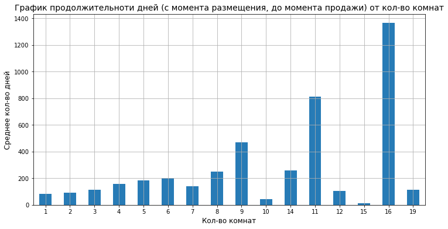

```python
room_group = (
    df.pivot_table(index='rooms', values='days_exposition', aggfunc=('count', 'median'))
    .sort_values('count', ascending=False)
)

fig, ax = plt.subplots()

room_group['median'].plot(kind='bar', ax=ax, grid=True, color='#277bb6')
fig.set_figwidth(12)    #  ширина
fig.set_figheight(6)    #  высота
plt.title('График продолжительноти дней (с момента размещения, до момента продажи) от кол-во комнат', size=14)
plt.xticks(rotation=0)
plt.xlabel('Кол-во комнат', size=12)
plt.ylabel('Среднее кол-во дней', size=12)

plt.show()
```

Действительно есть взаимосвязь роста продолжительности вплоть до 6 комнат, до 9 этажей если не учитывать вариант с 7 комнатами.

Посмотрим на графике зависимость даты публикации от количества дней размещения объявления:

Предварительно измененим тип данных у день публикации(`first_day_exposition`), так как это позволит нам производить вычисления связанное с датой, сделаем это через библиотеку pandas:

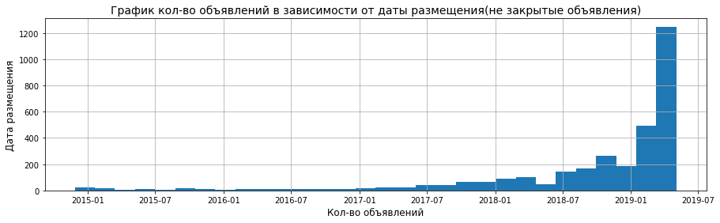

```python
df['first_day_exposition'] = pd.to_datetime(df['first_day_exposition'], format='%Y-%m-%dT%H:%M:%S')

plt.figure(figsize=(15,4))

df[df['days_exposition'].isna()]['first_day_exposition'].hist(bins=30)
plt.title('График кол-во объявлений в зависимости от даты размещения(не закрытые объявления)', size=14)
plt.xticks(rotation=0)
plt.xlabel('Кол-во объявлений', size=12)
plt.ylabel('Дата размещения', size=12)
plt.show()
```

Видим что большее количество не закрытых объявлений ближе к концу графика, возможно оно растет так как это срез таблицы за определенную дату.

Посмотрим на закрытые объявления:

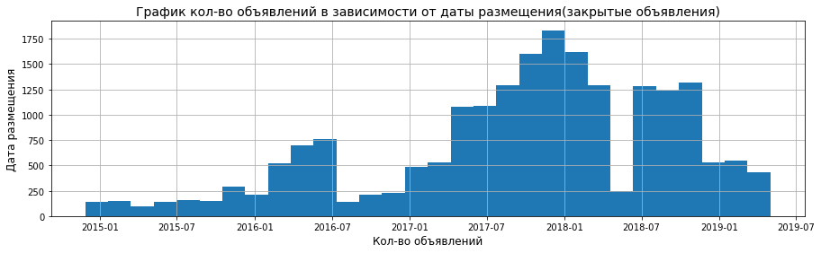

```python
plt.figure(figsize=(15,4))
df[~df['days_exposition'].isna()]['first_day_exposition'].hist(bins=30)
plt.title('График кол-во объявлений в зависимости от даты размещения(закрытые объявления)', size=14)
plt.xticks(rotation=0)
plt.xlabel('Кол-во объявлений', size=12)
plt.ylabel('Дата размещения', size=12)
plt.show()
```

Построим график с продолжительностью объявления с привязкой к дате открытия объявления:

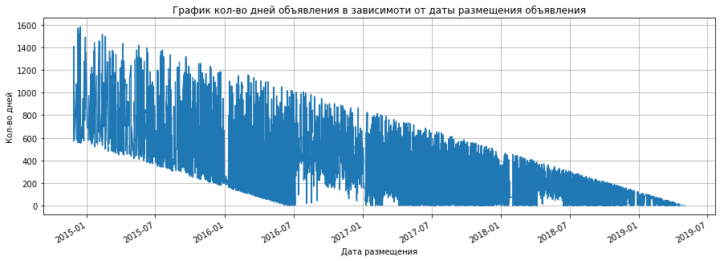

```python
df.plot(
    x='first_day_exposition',
    y='days_exposition',
    figsize=(15,5),
    grid=True,
    legend=False,
    xlabel='Дата размещения',
    ylabel='Кол-во дней',
    title='График кол-во дней объявления в зависимоти от даты размещения объявления'
);
```

Видим что график пересекает 0 в районе 2016 июля, то есть заполнять пропуски после этой даты будет не правильно т.к. они у неснятых с продажи объявлений.

Посмотрим на пропуске до и после этой даты:

```python
date_crop = dt(2016, 6, 1)

print('Пропусков до', date_crop,':' ,len(df.loc[(df['first_day_exposition'] < date_crop)&(df['days_exposition'].isna()),'days_exposition']))
print('Пропусков после', date_crop,':' ,len(df.loc[(df['first_day_exposition'] > date_crop)&(df['days_exposition'].isna()),'days_exposition']))
```

```
Пропусков до 2016-06-01 00:00:00 : 119
Пропусков после 2016-06-01 00:00:00 : 3047
```

С учетом что до нашей даты всего 119 объявлений (меньше 1 %) заменим все пропуски на -1 чтобы не искажать данные.

```python
df['days_exposition'] = df['days_exposition'].fillna(-1) #пустые ячейки заполним -1
df.isna().sum()
```

```
total_images            0
last_price              0
total_area              0
first_day_exposition    0
rooms                   0
ceiling_height          0
floors_total            0
living_area             0
floor                   0
is_apartment            0
studio                  0
open_plan               0
kitchen_area            0
balcony                 0
locality_name           0
airports_nearest        0
city_сenters_nearest    0
parks_around_3km        0
parks_nearest           0
ponds_around_3km        0
ponds_nearest           0
days_exposition         0
city_center_km          0
dtype: int64
```

Переведем часть типов данных к целым числам так как количество балконов, этажей, ближайших парков и озер должно быть целым числом.

Выведем 5 первых ячеек для проверки:

```python
type_list= ['floors_total', 'balcony','parks_nearest','ponds_nearest']

for col in type_list:
    df[col] = df[col].astype('int64')

df.head()
```

|  | total_images | last_price | total_area | first_day_exposition | rooms | ceiling_height | floors_total | living_area | floor | is_apartment | ... | balcony | locality_name | airports_nearest | city_сenters_nearest | parks_around_3km | parks_nearest | ponds_around_3km | ponds_nearest | days_exposition | city_center_km |
| --- | --- | --- | --- | --- | --- | --- | --- | --- | --- | --- | --- | --- | --- | --- | --- | --- | --- | --- | --- | --- | --- |
| 0 | 20 | 13000000.0 | 108.0 | 2019-03-07 | 3 | 2.700 | 16 | 51.0 | 8 | False | ... | 0 | Санкт-Петербург | 18863.0 | 16028.0 | 1.0 | 482 | 2.0 | 755 | -1.0 | 16.0 |
| 1 | 7 | 3350000.0 | 40.4 | 2018-12-04 | 1 | 2.630 | 11 | 18.6 | 1 | False | ... | 2 | Шушары | 12817.0 | 18603.0 | 0.0 | 375 | 0.0 | 524 | 81.0 | 19.0 |
| 2 | 10 | 5196000.0 | 56.0 | 2015-08-20 | 2 | 2.600 | 5 | 34.3 | 4 | False | ... | 0 | Санкт-Петербург | 21741.0 | 13933.0 | 1.0 | 90 | 2.0 | 574 | 558.0 | 14.0 |
| 3 | 0 | 64900000.0 | 159.0 | 2015-07-24 | 3 | 2.985 | 14 | 45.0 | 9 | False | ... | 0 | Санкт-Петербург | 28098.0 | 6800.0 | 2.0 | 84 | 3.0 | 234 | 424.0 | 7.0 |
| 4 | 2 | 10000000.0 | 100.0 | 2018-06-19 | 2 | 3.030 | 14 | 32.0 | 13 | False | ... | 0 | Санкт-Петербург | 31856.0 | 8098.0 | 2.0 | 112 | 1.0 | 48 | 121.0 | 8.0 |

5 rows × 23 columns

Если есть в таблице очевидные дубликати избавимся от них:

И посмотрим общую информацию:

```python
df = df.drop_duplicates()
df.info()
```

```
<class 'pandas.core.frame.DataFrame'>
Int64Index: 23453 entries, 0 to 23698
Data columns (total 23 columns):
 #   Column                Non-Null Count  Dtype
---  ------                --------------  -----
 0   total_images          23453 non-null  int64
 1   last_price            23453 non-null  float64
 2   total_area            23453 non-null  float64
 3   first_day_exposition  23453 non-null  datetime64[ns]
 4   rooms                 23453 non-null  int64
 5   ceiling_height        23453 non-null  float64
 6   floors_total          23453 non-null  int64
 7   living_area           23453 non-null  float64
 8   floor                 23453 non-null  int64
 9   is_apartment          23453 non-null  bool
 10  studio                23453 non-null  bool
 11  open_plan             23453 non-null  bool
 12  kitchen_area          23453 non-null  float64
 13  balcony               23453 non-null  int64
 14  locality_name         23453 non-null  object
 15  airports_nearest      23453 non-null  float64
 16  city_сenters_nearest  23453 non-null  float64
 17  parks_around_3km      23453 non-null  float64
 18  parks_nearest         23453 non-null  int64
 19  ponds_around_3km      23453 non-null  float64
 20  ponds_nearest         23453 non-null  int64
 21  days_exposition       23453 non-null  float64
 22  city_center_km        23453 non-null  float64
dtypes: bool(3), datetime64[ns](1), float64(11), int64(7), object(1)
memory usage: 3.8+ MB
```

### Вывод

При изучении данных мы обнаружили пропуски, так как часть строк заполнено "вручную" вторая генерировалась на основе местоположания объекта, то в блоке с ручнным вводом скорее всего просто проигнорировали ячейку, не каждый заполняет высоту потолков или наличее балкона.

В блоке с автоматическим заполнением появились пропуски скорее всего из за ошибки местоположения или не существующего адреса или его отсутствие.

## Расчёты и добавление результатов в таблицу

Добавим в таблицу стоимость за квадратный метр:

```python
df['price_m2'] = round(df['last_price'] / df['total_area'])
df.head()
```

|  | total_images | last_price | total_area | first_day_exposition | rooms | ceiling_height | floors_total | living_area | floor | is_apartment | ... | locality_name | airports_nearest | city_сenters_nearest | parks_around_3km | parks_nearest | ponds_around_3km | ponds_nearest | days_exposition | city_center_km | price_m2 |
| --- | --- | --- | --- | --- | --- | --- | --- | --- | --- | --- | --- | --- | --- | --- | --- | --- | --- | --- | --- | --- | --- |
| 0 | 20 | 13000000.0 | 108.0 | 2019-03-07 | 3 | 2.700 | 16 | 51.0 | 8 | False | ... | Санкт-Петербург | 18863.0 | 16028.0 | 1.0 | 482 | 2.0 | 755 | -1.0 | 16.0 | 120370.0 |
| 1 | 7 | 3350000.0 | 40.4 | 2018-12-04 | 1 | 2.630 | 11 | 18.6 | 1 | False | ... | Шушары | 12817.0 | 18603.0 | 0.0 | 375 | 0.0 | 524 | 81.0 | 19.0 | 82921.0 |
| 2 | 10 | 5196000.0 | 56.0 | 2015-08-20 | 2 | 2.600 | 5 | 34.3 | 4 | False | ... | Санкт-Петербург | 21741.0 | 13933.0 | 1.0 | 90 | 2.0 | 574 | 558.0 | 14.0 | 92786.0 |
| 3 | 0 | 64900000.0 | 159.0 | 2015-07-24 | 3 | 2.985 | 14 | 45.0 | 9 | False | ... | Санкт-Петербург | 28098.0 | 6800.0 | 2.0 | 84 | 3.0 | 234 | 424.0 | 7.0 | 408176.0 |
| 4 | 2 | 10000000.0 | 100.0 | 2018-06-19 | 2 | 3.030 | 14 | 32.0 | 13 | False | ... | Санкт-Петербург | 31856.0 | 8098.0 | 2.0 | 112 | 1.0 | 48 | 121.0 | 8.0 | 100000.0 |

5 rows × 24 columns

Напишем функцию `floor_group` для классификации по этажу:

- первый
- поледний
- другой

Проверим ее на тестовом датафрейме:

```python
def floor_group(row):

    floor = row['floor']
    floors_total = row['floors_total']

    if floor == 1:
        return 'первый'
    if floor == floors_total:
        return 'последний'
    return 'другой'


#для проверки сделаем серию pandas и запустим нашу функцию
row_values = [1,5]
row_columns = ['floor','floors_total']

row = pd.Series(data=row_values, index=row_columns)

floor_group(row)
```

```
'первый'
```

Применим нашу функцию к нашей базе и выведем первые 5 ячеек для проверки:

```python
df['floor_category'] = df.apply(floor_group, axis=1)
df.head(5)
```

|  | total_images | last_price | total_area | first_day_exposition | rooms | ceiling_height | floors_total | living_area | floor | is_apartment | ... | airports_nearest | city_сenters_nearest | parks_around_3km | parks_nearest | ponds_around_3km | ponds_nearest | days_exposition | city_center_km | price_m2 | floor_category |
| --- | --- | --- | --- | --- | --- | --- | --- | --- | --- | --- | --- | --- | --- | --- | --- | --- | --- | --- | --- | --- | --- |
| 0 | 20 | 13000000.0 | 108.0 | 2019-03-07 | 3 | 2.700 | 16 | 51.0 | 8 | False | ... | 18863.0 | 16028.0 | 1.0 | 482 | 2.0 | 755 | -1.0 | 16.0 | 120370.0 | другой |
| 1 | 7 | 3350000.0 | 40.4 | 2018-12-04 | 1 | 2.630 | 11 | 18.6 | 1 | False | ... | 12817.0 | 18603.0 | 0.0 | 375 | 0.0 | 524 | 81.0 | 19.0 | 82921.0 | первый |
| 2 | 10 | 5196000.0 | 56.0 | 2015-08-20 | 2 | 2.600 | 5 | 34.3 | 4 | False | ... | 21741.0 | 13933.0 | 1.0 | 90 | 2.0 | 574 | 558.0 | 14.0 | 92786.0 | другой |
| 3 | 0 | 64900000.0 | 159.0 | 2015-07-24 | 3 | 2.985 | 14 | 45.0 | 9 | False | ... | 28098.0 | 6800.0 | 2.0 | 84 | 3.0 | 234 | 424.0 | 7.0 | 408176.0 | другой |
| 4 | 2 | 10000000.0 | 100.0 | 2018-06-19 | 2 | 3.030 | 14 | 32.0 | 13 | False | ... | 31856.0 | 8098.0 | 2.0 | 112 | 1.0 | 48 | 121.0 | 8.0 | 100000.0 | другой |

5 rows × 25 columns

Добавим соотношение жилой и общей площади, а также отношение площади кухни к общей и посмотрим первые 5 ячеек для проверки:

```python
df['ratio_living_total'] = round(df['living_area'] / df['total_area'] * 100)
df['ratio_kitchen_total'] = round(df['kitchen_area'] / df['total_area'] * 100)
df.head()
```

|  | total_images | last_price | total_area | first_day_exposition | rooms | ceiling_height | floors_total | living_area | floor | is_apartment | ... | parks_around_3km | parks_nearest | ponds_around_3km | ponds_nearest | days_exposition | city_center_km | price_m2 | floor_category | ratio_living_total | ratio_kitchen_total |
| --- | --- | --- | --- | --- | --- | --- | --- | --- | --- | --- | --- | --- | --- | --- | --- | --- | --- | --- | --- | --- | --- |
| 0 | 20 | 13000000.0 | 108.0 | 2019-03-07 | 3 | 2.700 | 16 | 51.0 | 8 | False | ... | 1.0 | 482 | 2.0 | 755 | -1.0 | 16.0 | 120370.0 | другой | 47.0 | 23.0 |
| 1 | 7 | 3350000.0 | 40.4 | 2018-12-04 | 1 | 2.630 | 11 | 18.6 | 1 | False | ... | 0.0 | 375 | 0.0 | 524 | 81.0 | 19.0 | 82921.0 | первый | 46.0 | 27.0 |
| 2 | 10 | 5196000.0 | 56.0 | 2015-08-20 | 2 | 2.600 | 5 | 34.3 | 4 | False | ... | 1.0 | 90 | 2.0 | 574 | 558.0 | 14.0 | 92786.0 | другой | 61.0 | 15.0 |
| 3 | 0 | 64900000.0 | 159.0 | 2015-07-24 | 3 | 2.985 | 14 | 45.0 | 9 | False | ... | 2.0 | 84 | 3.0 | 234 | 424.0 | 7.0 | 408176.0 | другой | 28.0 | 6.0 |
| 4 | 2 | 10000000.0 | 100.0 | 2018-06-19 | 2 | 3.030 | 14 | 32.0 | 13 | False | ... | 2.0 | 112 | 1.0 | 48 | 121.0 | 8.0 | 100000.0 | другой | 32.0 | 41.0 |

5 rows × 27 columns

Мы подготовили наши данные для дальнейшего анализа.

## Исследовательский анализ данных

Построим графики для визуального изучения параметров, начнем с графика цены `last_price`:

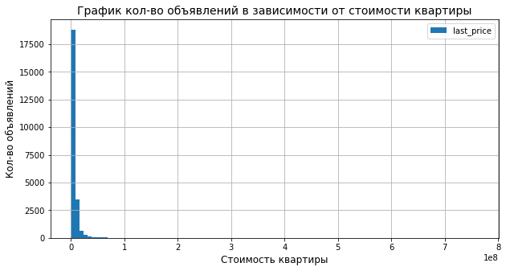

```python
df.plot(
    kind='hist',
    y='last_price',
    bins=100,
    figsize=(10,5),
    grid=True
)

plt.title('График кол-во объявлений в зависимости от стоимости квартиры', size=14)
plt.xticks(rotation=0)
plt.xlabel('Стоимость квартиры', size=12)
plt.ylabel('Кол-во объявлений', size=12)
plt.show()
```

Все основные значения в диапозоне от 0 до 10 000 000.

Зададим диапазон от 0 до 20 000 000 чтобы пока не отбросить лишнее:

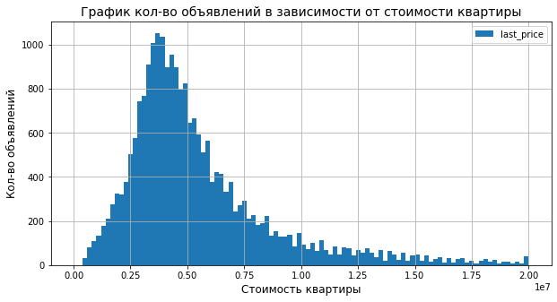

```python
df.plot(
    kind='hist',
    y='last_price',
    bins=100,
    figsize=(10,5),
    grid=True,
    range=(0,20000000)
);
plt.title('График кол-во объявлений в зависимости от стоимости квартиры', size=14)
plt.xticks(rotation=0)
plt.xlabel('Стоимость квартиры', size=12)
plt.ylabel('Кол-во объявлений', size=12)
plt.show()
```

Хорошо, график стал выглядеть лучше, видно что больше всего квартир со стоимостью от 2 до 7 млн.рублей, перейдем к общей площади:

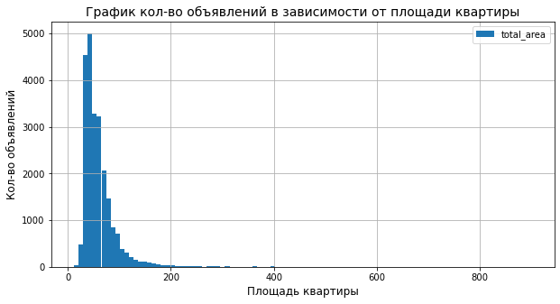

```python
df.plot(
    kind='hist',
    y='total_area',
    bins=100,
    figsize=(10,5),
    grid=True
)

plt.title('График кол-во объявлений в зависимости от площади квартиры', size=14)
plt.xticks(rotation=0)
plt.xlabel('Площадь квартиры', size=12)
plt.ylabel('Кол-во объявлений', size=12)
plt.show()
```

Так как объекты с площадью более 250 кв.м редки ограничемся этим значением:

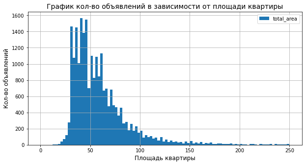

```python
df.plot(
    kind='hist',
    y='total_area',
    bins=100,
    figsize=(10,5),
    grid=True,
    range=(0,250)
)

plt.title('График кол-во объявлений в зависимости от площади квартиры', size=14)
plt.xticks(rotation=0)
plt.xlabel('Площадь квартиры', size=12)
plt.ylabel('Кол-во объявлений', size=12)
plt.show()
```

Хорошо, посмотрим ковое распределение у количества комнат:

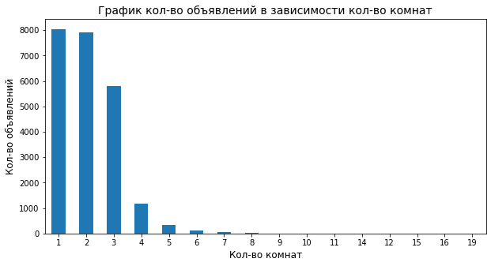

```python
df.value_counts('rooms').plot(kind='bar', figsize=(10,5))

plt.title('График кол-во объявлений в зависимости кол-во комнат', size=14)
plt.xticks(rotation=0)
plt.xlabel('Кол-во комнат', size=12)
plt.ylabel('Кол-во объявлений', size=12)
plt.show()
```

Больше 10 комнат единичны, ограничимся 10 комнатами:

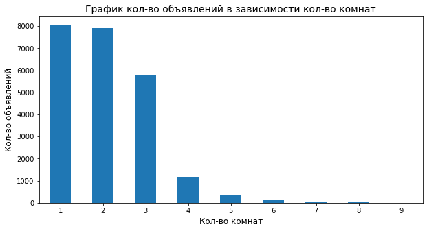

```
Процент 1-2-3 комнатных квартир от всех: 93 %
```

```python
df.query('rooms < 10').value_counts('rooms').plot(kind='bar', figsize=(10,5))

plt.title('График кол-во объявлений в зависимости кол-во комнат', size=14)
plt.xticks(rotation=0)
plt.xlabel('Кол-во комнат', size=12)
plt.ylabel('Кол-во объявлений', size=12)
plt.show()

print('Процент 1-2-3 комнатных квартир от всех:', round(df.query('rooms <= 3').shape[0]/df.shape[0] * 100),'%')
```

переходим к высоте потолка выведем график:

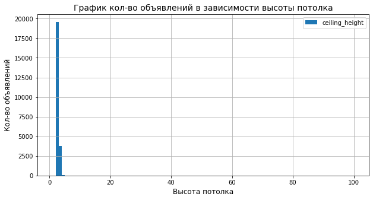

```python
df.plot(
    kind='hist',
    y='ceiling_height',
    bins=100,
    figsize=(10,5),
    grid=True
)

plt.title('График кол-во объявлений в зависимости высоты потолка', size=14)
plt.xticks(rotation=0)
plt.xlabel('Высота потолка', size=12)
plt.ylabel('Кол-во объявлений', size=12)
plt.show()
```

Тут явно есть ошибочные значения, квартиры с потолками больше 5 метров уже больше похожи на склады, а уж 100 метровые тем более.

Ограничемся от 2 до 5 м.:

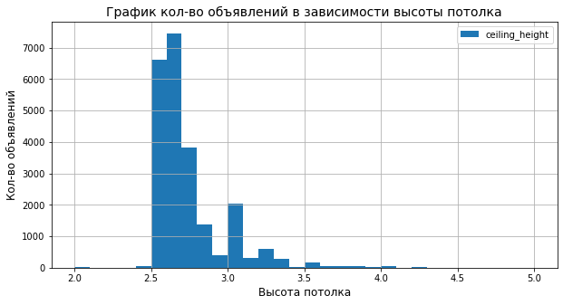

```python
df.plot(
    kind='hist',
    y='ceiling_height',
    bins=30,
    figsize=(10,5),
    grid=True,
    range=(2,5)
)

plt.title('График кол-во объявлений в зависимости высоты потолка', size=14)
plt.xticks(rotation=0)
plt.xlabel('Высота потолка', size=12)
plt.ylabel('Кол-во объявлений', size=12)
plt.show()
```

Видим что больше всего квартир с потолками от 2,5 до 3,1 метра.

Посмотрим какой процент данных по нашим ограничениям:

- стоимость от 1 000 000 до 20 000 000:
- площадь не более 250 м2
- комнат не более 10
- высота потолка менее 5 метров

```python
round(len(df.query(
    '1000000 < last_price < 20000000 and total_area < 250 and rooms < 10 and ceiling_height < 5'
))/df.shape[0] * 100, 2)
```

```
95.72
```

При таких параметрах мы удалим 4,3% данных.

Выведем диаграмму размаха по времени продаж:

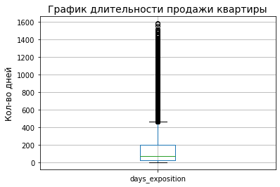

```python
df.boxplot(column='days_exposition')

plt.title('График длительности продажи квартиры', size=14)
plt.xticks(rotation=0)
plt.ylabel('Кол-во дней', size=12)
plt.show()
```

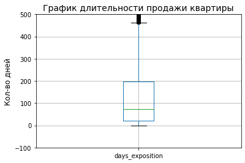

```python
plt.ylim(-100, 500)
df.boxplot(column='days_exposition')

plt.title('График длительности продажи квартиры', size=14)
plt.xticks(rotation=0)
plt.ylabel('Кол-во дней', size=12)
plt.show();
```

Посмотрим общие данные через `describe` чтобы увидеть редкие и аномальные значения:

```python
round(df.describe())
```

|  | total_images | last_price | total_area | rooms | ceiling_height | floors_total | living_area | floor | kitchen_area | balcony | ... | city_сenters_nearest | parks_around_3km | parks_nearest | ponds_around_3km | ponds_nearest | days_exposition | city_center_km | price_m2 | ratio_living_total | ratio_kitchen_total |
| --- | --- | --- | --- | --- | --- | --- | --- | --- | --- | --- | --- | --- | --- | --- | --- | --- | --- | --- | --- | --- | --- |
| count | 23453.0 | 23453.0 | 23453.0 | 23453.0 | 23453.0 | 23453.0 | 23453.0 | 23453.0 | 23453.0 | 23453.0 | ... | 23453.0 | 23453.0 | 23453.0 | 23453.0 | 23453.0 | 23453.0 | 23453.0 | 23453.0 | 23453.0 | 23453.0 |
| mean | 10.0 | 6568035.0 | 61.0 | 2.0 | 3.0 | 11.0 | 34.0 | 6.0 | 10.0 | 1.0 | ... | 11514.0 | 0.0 | 440.0 | 1.0 | 527.0 | 157.0 | 12.0 | 99356.0 | 56.0 | 19.0 |
| std | 6.0 | 10928364.0 | 36.0 | 1.0 | 1.0 | 7.0 | 22.0 | 5.0 | 6.0 | 1.0 | ... | 9645.0 | 1.0 | 245.0 | 1.0 | 182.0 | 214.0 | 10.0 | 50477.0 | 11.0 | 7.0 |
| min | 0.0 | 12190.0 | 12.0 | 1.0 | 1.0 | 1.0 | 2.0 | 1.0 | 1.0 | 0.0 | ... | -1.0 | -1.0 | -1.0 | 0.0 | -1.0 | -1.0 | -0.0 | 112.0 | 2.0 | 2.0 |
| 25% | 6.0 | 3450000.0 | 40.0 | 1.0 | 3.0 | 5.0 | 18.0 | 2.0 | 7.0 | 0.0 | ... | 3876.0 | 0.0 | 229.0 | 0.0 | 465.0 | 22.0 | 4.0 | 76471.0 | 49.0 | 13.0 |
| 50% | 9.0 | 4650000.0 | 52.0 | 2.0 | 3.0 | 9.0 | 30.0 | 4.0 | 9.0 | 0.0 | ... | 11740.0 | 0.0 | 445.0 | 1.0 | 516.0 | 74.0 | 12.0 | 94898.0 | 57.0 | 17.0 |
| 75% | 14.0 | 6800000.0 | 70.0 | 3.0 | 3.0 | 16.0 | 43.0 | 8.0 | 12.0 | 1.0 | ... | 15731.0 | 1.0 | 529.0 | 3.0 | 599.0 | 199.0 | 16.0 | 114103.0 | 64.0 | 23.0 |
| max | 50.0 | 763000000.0 | 900.0 | 19.0 | 100.0 | 60.0 | 410.0 | 33.0 | 112.0 | 5.0 | ... | 65968.0 | 3.0 | 3190.0 | 3.0 | 1344.0 | 1580.0 | 66.0 | 1907500.0 | 152.0 | 79.0 |

8 rows × 21 columns

Первое что бросается в 100 метровые потолки при 3 метров укладывается в нормальные показатели.

Посмотрим потолки больше 5 метров:

Так же потолки ниже 2.3 метров подозрительны их тоже посмотрим:

```python
display(df.query('ceiling_height > 5').sort_values('ceiling_height', ascending=False))
df.query('ceiling_height < 2.3').sort_values('ceiling_height', ascending=False)
```

|  | total_images | last_price | total_area | first_day_exposition | rooms | ceiling_height | floors_total | living_area | floor | is_apartment | ... | parks_around_3km | parks_nearest | ponds_around_3km | ponds_nearest | days_exposition | city_center_km | price_m2 | floor_category | ratio_living_total | ratio_kitchen_total |
| --- | --- | --- | --- | --- | --- | --- | --- | --- | --- | --- | --- | --- | --- | --- | --- | --- | --- | --- | --- | --- | --- |
| 22869 | 0 | 15000000.0 | 25.0 | 2018-07-25 | 1 | 100.0 | 5 | 14.000 | 5 | True | ... | 1.0 | 223 | 3.0 | 30 | 19.0 | 8.0 | 600000.0 | последний | 56.0 | 44.0 |
| 22336 | 19 | 9999000.0 | 92.4 | 2019-04-05 | 2 | 32.0 | 6 | 55.500 | 5 | False | ... | 0.0 | 485 | 3.0 | 511 | -1.0 | 4.0 | 108214.0 | другой | 60.0 | 18.0 |
| 3148 | 14 | 2900000.0 | 75.0 | 2018-11-12 | 3 | 32.0 | 3 | 53.000 | 2 | False | ... | -1.0 | 229 | 3.0 | 516 | -1.0 | -0.0 | 38667.0 | другой | 71.0 | 11.0 |
| 21377 | 19 | 4900000.0 | 42.0 | 2017-04-18 | 1 | 27.5 | 24 | 37.700 | 19 | False | ... | 0.0 | 458 | 0.0 | 498 | 61.0 | 10.0 | 116667.0 | другой | 90.0 | 26.0 |
| 22938 | 14 | 4000000.0 | 98.0 | 2018-03-15 | 4 | 27.0 | 2 | 73.000 | 2 | True | ... | -1.0 | 229 | 3.0 | 516 | 27.0 | -0.0 | 40816.0 | последний | 74.0 | 9.0 |
| 10773 | 8 | 3800000.0 | 58.0 | 2017-10-13 | 2 | 27.0 | 10 | 30.100 | 3 | False | ... | 0.0 | 827 | 1.0 | 682 | 71.0 | 22.0 | 65517.0 | другой | 52.0 | 14.0 |
| 2158 | 15 | 1500000.0 | 42.0 | 2017-12-23 | 2 | 27.0 | 2 | 29.000 | 2 | False | ... | -1.0 | 229 | 3.0 | 516 | -1.0 | -0.0 | 35714.0 | последний | 69.0 | 13.0 |
| 21824 | 20 | 2450000.0 | 44.0 | 2019-02-12 | 2 | 27.0 | 2 | 38.000 | 2 | False | ... | -1.0 | 229 | 3.0 | 516 | -1.0 | -0.0 | 55682.0 | последний | 86.0 | 20.0 |
| 20478 | 11 | 8000000.0 | 45.0 | 2017-07-18 | 1 | 27.0 | 4 | 22.000 | 2 | False | ... | 0.0 | 415 | 3.0 | 449 | 429.0 | 3.0 | 177778.0 | другой | 49.0 | 22.0 |
| 5246 | 0 | 2500000.0 | 54.0 | 2017-10-13 | 2 | 27.0 | 5 | 30.000 | 3 | False | ... | -1.0 | 229 | 3.0 | 516 | 540.0 | -0.0 | 46296.0 | другой | 56.0 | 17.0 |
| 5807 | 17 | 8150000.0 | 80.0 | 2019-01-09 | 2 | 27.0 | 36 | 41.000 | 13 | False | ... | 0.0 | 394 | 3.0 | 80 | 38.0 | 20.0 | 101875.0 | другой | 51.0 | 15.0 |
| 17857 | 1 | 3900000.0 | 56.0 | 2017-12-22 | 3 | 27.0 | 5 | 33.000 | 4 | False | ... | 0.0 | 529 | 0.0 | 535 | 73.0 | 16.0 | 69643.0 | другой | 59.0 | 17.0 |
| 5669 | 4 | 4400000.0 | 50.0 | 2017-08-08 | 2 | 26.0 | 9 | 21.300 | 3 | False | ... | 1.0 | 305 | 0.0 | 614 | 267.0 | 11.0 | 88000.0 | другой | 43.0 | 14.0 |
| 18545 | 6 | 3750000.0 | 43.0 | 2019-03-18 | 2 | 25.0 | 5 | 29.000 | 3 | False | ... | 1.0 | 540 | 0.0 | 437 | 12.0 | 8.0 | 87209.0 | другой | 67.0 | 20.0 |
| 14382 | 9 | 1700000.0 | 35.0 | 2015-12-04 | 1 | 25.0 | 5 | 20.000 | 2 | False | ... | -1.0 | 229 | 3.0 | 516 | 206.0 | -0.0 | 48571.0 | другой | 57.0 | 23.0 |
| 355 | 17 | 3600000.0 | 55.2 | 2018-07-12 | 2 | 25.0 | 5 | 32.000 | 2 | False | ... | -1.0 | 229 | 3.0 | 516 | 259.0 | -0.0 | 65217.0 | другой | 58.0 | 16.0 |
| 9379 | 5 | 3950000.0 | 42.0 | 2017-03-26 | 3 | 25.0 | 5 | 30.000 | 2 | False | ... | 0.0 | 433 | 0.0 | 541 | -1.0 | 14.0 | 94048.0 | другой | 71.0 | 12.0 |
| 6246 | 6 | 3300000.0 | 44.4 | 2019-03-25 | 2 | 25.0 | 5 | 31.300 | 5 | False | ... | 1.0 | 417 | 2.0 | 73 | -1.0 | 51.0 | 74324.0 | последний | 70.0 | 13.0 |
| 4643 | 0 | 4300000.0 | 45.0 | 2018-02-01 | 2 | 25.0 | 9 | 30.000 | 2 | False | ... | 1.0 | 658 | 1.0 | 331 | 181.0 | 13.0 | 95556.0 | другой | 67.0 | 16.0 |
| 11285 | 0 | 1950000.0 | 37.0 | 2019-03-20 | 1 | 25.0 | 5 | 17.000 | 4 | False | ... | -1.0 | 229 | 3.0 | 516 | 18.0 | -0.0 | 52703.0 | другой | 46.0 | 24.0 |
| 5076 | 0 | 3850000.0 | 30.5 | 2018-10-03 | 1 | 24.0 | 5 | 19.500 | 1 | True | ... | 3.0 | 397 | 1.0 | 578 | 7.0 | 8.0 | 126230.0 | первый | 64.0 | 18.0 |
| 20507 | 12 | 5950000.0 | 60.0 | 2018-02-19 | 2 | 22.6 | 14 | 35.000 | 11 | False | ... | 0.0 | 541 | 0.0 | 642 | 40.0 | 13.0 | 99167.0 | другой | 58.0 | 22.0 |
| 17496 | 15 | 6700000.0 | 92.9 | 2019-02-19 | 3 | 20.0 | 17 | 53.200 | 14 | False | ... | 1.0 | 967 | 0.0 | 578 | -1.0 | 15.0 | 72121.0 | другой | 57.0 | 13.0 |
| 15061 | 19 | 5600000.0 | 56.4 | 2018-05-11 | 2 | 14.0 | 14 | 32.400 | 5 | False | ... | 0.0 | 433 | 0.0 | 541 | 315.0 | 14.0 | 99291.0 | другой | 57.0 | 16.0 |
| 22309 | 20 | 5300000.0 | 45.0 | 2017-09-30 | 1 | 10.3 | 16 | 15.500 | 15 | False | ... | 2.0 | 440 | 2.0 | 450 | 136.0 | 12.0 | 117778.0 | другой | 34.0 | 20.0 |
| 5863 | 20 | 5650000.0 | 45.0 | 2018-08-15 | 1 | 8.3 | 16 | 19.300 | 14 | False | ... | 0.0 | 475 | 1.0 | 613 | 14.0 | 11.0 | 125556.0 | другой | 43.0 | 18.0 |
| 15743 | 14 | 5600000.0 | 67.0 | 2016-11-11 | 3 | 8.0 | 16 | 41.000 | 1 | False | ... | 1.0 | 723 | 0.0 | 614 | 474.0 | 11.0 | 83582.0 | первый | 61.0 | 12.0 |
| 17442 | 0 | 5350000.0 | 54.0 | 2015-06-16 | 2 | 8.0 | 5 | 29.000 | 2 | False | ... | 0.0 | 334 | 0.0 | 450 | 469.0 | 28.0 | 99074.0 | другой | 54.0 | 16.0 |
| 3474 | 3 | 1400000.0 | 30.0 | 2018-03-16 | 1 | 8.0 | 5 | 15.300 | 2 | False | ... | -1.0 | 229 | 3.0 | 516 | 125.0 | -0.0 | 46667.0 | другой | 51.0 | 24.0 |
| 20264 | 17 | 119000000.0 | 187.6 | 2017-07-10 | 4 | 6.0 | 7 | 147.000 | 7 | False | ... | 3.0 | 484 | 1.0 | 305 | 259.0 | 6.0 | 634328.0 | последний | 78.0 | 8.0 |
| 1388 | 20 | 59800000.0 | 399.0 | 2015-01-21 | 5 | 5.6 | 6 | 91.785 | 6 | False | ... | 2.0 | 149 | 2.0 | 577 | 719.0 | 7.0 | 149875.0 | последний | 23.0 | 4.0 |
| 7578 | 17 | 38000000.0 | 143.0 | 2017-11-02 | 3 | 5.5 | 5 | 83.000 | 5 | False | ... | 3.0 | 479 | 0.0 | 475 | -1.0 | 6.0 | 265734.0 | последний | 58.0 | 20.0 |
| 12628 | 14 | 3900000.0 | 50.0 | 2018-03-29 | 1 | 5.3 | 5 | 17.600 | 5 | False | ... | 1.0 | 505 | 1.0 | 92 | 8.0 | 4.0 | 78000.0 | последний | 35.0 | 18.0 |
| 1026 | 20 | 155000000.0 | 310.0 | 2018-10-12 | 5 | 5.3 | 3 | 190.000 | 3 | False | ... | 0.0 | 445 | 1.0 | 603 | -1.0 | 5.0 | 500000.0 | последний | 61.0 | 20.0 |
| 464 | 15 | 66571000.0 | 280.3 | 2015-06-11 | 6 | 5.2 | 8 | 159.500 | 7 | False | ... | 3.0 | 187 | 1.0 | 616 | 578.0 | 7.0 | 237499.0 | другой | 57.0 | 8.0 |

35 rows × 27 columns

|  | total_images | last_price | total_area | first_day_exposition | rooms | ceiling_height | floors_total | living_area | floor | is_apartment | ... | parks_around_3km | parks_nearest | ponds_around_3km | ponds_nearest | days_exposition | city_center_km | price_m2 | floor_category | ratio_living_total | ratio_kitchen_total |
| --- | --- | --- | --- | --- | --- | --- | --- | --- | --- | --- | --- | --- | --- | --- | --- | --- | --- | --- | --- | --- | --- |
| 17794 | 1 | 2300000.0 | 58.60 | 2016-05-12 | 3 | 2.25 | 5 | 44.100002 | 3 | False | ... | -1.0 | 229 | 3.0 | 516 | 45.0 | -0.0 | 39249.0 | другой | 75.0 | 9.0 |
| 12755 | 2 | 1400000.0 | 22.50 | 2017-09-21 | 1 | 2.20 | 2 | 18.000000 | 2 | False | ... | -1.0 | 229 | 3.0 | 516 | 45.0 | -0.0 | 62222.0 | последний | 80.0 | 20.0 |
| 552 | 11 | 2999000.0 | 33.50 | 2017-03-30 | 1 | 2.00 | 15 | 17.500000 | 6 | False | ... | 1.0 | 520 | 1.0 | 949 | 270.0 | 12.0 | 89522.0 | другой | 52.0 | 19.0 |
| 2572 | 4 | 2400000.0 | 62.00 | 2018-12-27 | 3 | 2.00 | 5 | 40.000000 | 4 | False | ... | -1.0 | 229 | 3.0 | 516 | -1.0 | -0.0 | 38710.0 | другой | 65.0 | 10.0 |
| 4212 | 1 | 2120000.0 | 35.43 | 2017-12-18 | 1 | 2.00 | 18 | 16.600000 | 9 | False | ... | -1.0 | 229 | 3.0 | 516 | 36.0 | -0.0 | 59836.0 | другой | 47.0 | 25.0 |
| 5850 | 9 | 1650000.0 | 35.50 | 2018-05-29 | 1 | 2.00 | 5 | 17.600000 | 5 | False | ... | -1.0 | 229 | 3.0 | 516 | 100.0 | -0.0 | 46479.0 | последний | 50.0 | 25.0 |
| 11352 | 4 | 3300000.0 | 36.00 | 2017-06-18 | 1 | 2.00 | 17 | 15.200000 | 12 | False | ... | 0.0 | 329 | 0.0 | 377 | 53.0 | 27.0 | 91667.0 | другой | 42.0 | 28.0 |
| 16446 | 6 | 12300000.0 | 88.30 | 2019-03-12 | 3 | 2.00 | 5 | 63.900000 | 2 | False | ... | 1.0 | 568 | 1.0 | 154 | -1.0 | 8.0 | 139298.0 | другой | 72.0 | 14.0 |
| 16884 | 0 | 1500000.0 | 33.00 | 2018-10-03 | 1 | 2.00 | 5 | 20.000000 | 5 | False | ... | -1.0 | 229 | 3.0 | 516 | 6.0 | -0.0 | 45455.0 | последний | 61.0 | 18.0 |
| 19098 | 7 | 2700000.0 | 56.00 | 2018-02-04 | 3 | 2.00 | 5 | 46.000000 | 1 | False | ... | -1.0 | 229 | 3.0 | 516 | 282.0 | -0.0 | 48214.0 | первый | 82.0 | 11.0 |
| 19329 | 5 | 1700000.0 | 40.00 | 2018-07-15 | 2 | 2.00 | 9 | 30.500000 | 8 | False | ... | -1.0 | 229 | 3.0 | 516 | 45.0 | -0.0 | 42500.0 | другой | 76.0 | 22.0 |
| 20520 | 9 | 3600000.0 | 38.00 | 2018-07-05 | 1 | 2.00 | 12 | 15.000000 | 9 | False | ... | -1.0 | 229 | 3.0 | 516 | 62.0 | -0.0 | 94737.0 | другой | 39.0 | 31.0 |
| 22960 | 17 | 2300000.0 | 53.60 | 2018-10-18 | 2 | 2.00 | 2 | 19.000000 | 1 | False | ... | -1.0 | 229 | 3.0 | 516 | -1.0 | -0.0 | 42910.0 | первый | 35.0 | 19.0 |
| 16934 | 5 | 4100000.0 | 40.00 | 2017-10-17 | 1 | 1.75 | 37 | 17.400000 | 5 | False | ... | 0.0 | 394 | 3.0 | 80 | 71.0 | 20.0 | 102500.0 | другой | 43.0 | 21.0 |
| 5712 | 5 | 1500000.0 | 42.80 | 2017-08-14 | 2 | 1.20 | 2 | 27.500000 | 1 | False | ... | -1.0 | 229 | 3.0 | 516 | 248.0 | -0.0 | 35047.0 | первый | 64.0 | 12.0 |
| 22590 | 16 | 6000000.0 | 55.00 | 2018-10-31 | 2 | 1.00 | 12 | 32.400000 | 7 | False | ... | 2.0 | 293 | 2.0 | 289 | 13.0 | 14.0 | 109091.0 | другой | 59.0 | 18.0 |

16 rows × 27 columns

Всего c большими потолками 35 строк и 16 маленькими: Судя по некоторым строкам свыше 10 метров могли допустить ошибку сместив точку на один символ написав высоту потолков в децеметрах так появились значения от 22.6 до 32.

Строка с значением 100 могла появилаться из за человеческой ошибки перепутали общую площадь и высоту потолка правда если допустить ошибку выше сюда же так как 25 метров все равно многовато.

Другие хоть и редкие, но вполне могут существовать большая площадь, большая стоимость и.тд.

Посмотрим влияния параметров на стоимость пока без учета местоположения(центр, аэропорт, парки и водоемы): Возьмем стоимость, общую площадь, кол-во комнат, высоту потолков, отношение жилой и кухоных площадей к общей.

Выведем графики рассеивания и таблицу корреляции:

|  | last_price | total_area | rooms | ceiling_height | ratio_living_total | ratio_kitchen_total |
| --- | --- | --- | --- | --- | --- | --- |
| last_price | 1.000000 | 0.775548 | 0.511400 | 0.498465 | -0.004017 | -0.171628 |
| total_area | 0.775548 | 1.000000 | 0.799473 | 0.398461 | 0.182037 | -0.416651 |
| rooms | 0.511400 | 0.799473 | 1.000000 | 0.216926 | 0.554017 | -0.626031 |
| ceiling_height | 0.498465 | 0.398461 | 0.216926 | 1.000000 | -0.029862 | 0.001723 |
| ratio_living_total | -0.004017 | 0.182037 | 0.554017 | -0.029862 | 1.000000 | -0.583527 |
| ratio_kitchen_total | -0.171628 | -0.416651 | -0.626031 | 0.001723 | -0.583527 | 1.000000 |

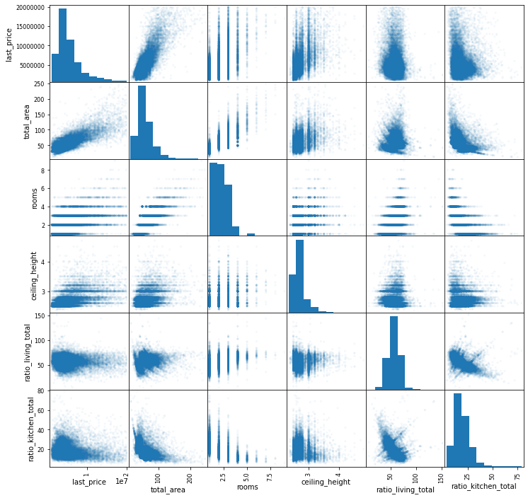

```python
crop_df = df.query('1000000 < last_price < 20000000 and total_area < 250 and rooms < 10 and 2.3 < ceiling_height < 5').copy()

main_crop_df = crop_df[['last_price','total_area','rooms','ceiling_height','ratio_living_total','ratio_kitchen_total']]

pd.plotting.scatter_matrix(main_crop_df, figsize=(12, 12), alpha=0.05);
main_crop_df.corr()
```

Есть зависимоти общей стоимости от общей площади что не удивительно (0.8)

Так же как и общая площидь коррелируется с количеством комнат (0.8)

Наблюдаем обратную зависимость количество комнат к соотношению кухонной площади к общей (-0,6)

И обратная зависимоть у соотношение жилой к общей и кухонной к общей площадям (-0,6)

Посмотрим как влияет общая площадь на стоимость кв.м.:

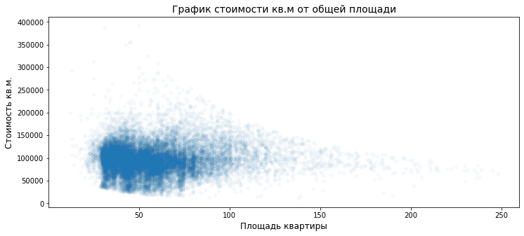

```python
crop_df.plot(x='total_area', y='price_m2', kind='scatter',figsize=(12, 5), alpha=0.03);
crop_df['price_m2'].corr(crop_df['total_area'])

plt.title('График стоимости кв.м от общей площади', size=14)
plt.xticks(rotation=0)
plt.xlabel('Площадь квартиры', size=12)
plt.ylabel('Стоимость кв.м.', size=12)
plt.show()
```

Видем что с увелечением площади стоимоть уменьшается и за площадь в 200кв.м стоимость непревышает 100тр. за кв.м., тогда как при площади в 50 кв.м. стоимоть может быть и в 200 т.р. за кв.м.

Посмотрим как влияет количество комнат на стоимость кв.м.:

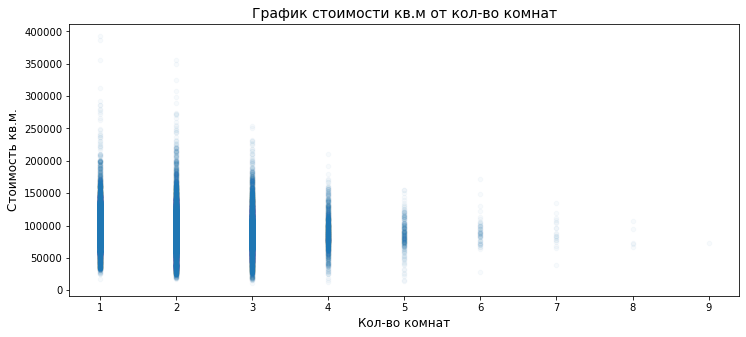

```python
crop_df.plot(x='rooms', y='price_m2', kind='scatter', alpha=0.03, figsize=(12, 5));
crop_df['price_m2'].corr(crop_df['rooms'])


plt.title('График стоимости кв.м от кол-во комнат', size=14)
plt.xticks(rotation=0)
plt.xlabel('Кол-во комнат', size=12)
plt.ylabel('Стоимость кв.м.', size=12)
plt.show()
```

Тут как и в предыдущем примере с общей площадью чем больше комнат(соответствено и больше площадь) тем цена за кв.м. стабилизируется в районе 100тр. за кв.м.

Проверим как этажность влияет на стоимость кв.м.

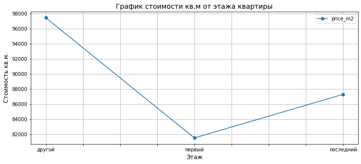

```python
(
    crop_df
    .groupby(['floor_category'])
    .agg({'price_m2':'median'}).
    plot(
        y='price_m2',
        style='o-',
        grid=True,
        figsize=(12, 5)
    )
)

plt.title('График стоимости кв.м от этажа квартиры', size=14)
plt.xticks(rotation=0)
plt.xlabel('Этаж', size=12)
plt.ylabel('Стоимость кв.м.', size=12)
plt.show()
```

- Самый дешевый первый этаж - чуть ниже **82 тр.**
- Средняя стоимость за последний - чуть выше **87 тр.**
- Ну и если этаж не первый и не последний то средняя цена уже почти **97,5 тр.**

Посмотрим изменение стоимоcти жилья в зависимости от степени удаленности от центра:

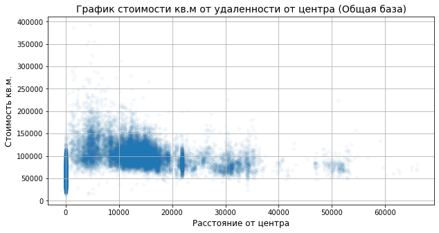

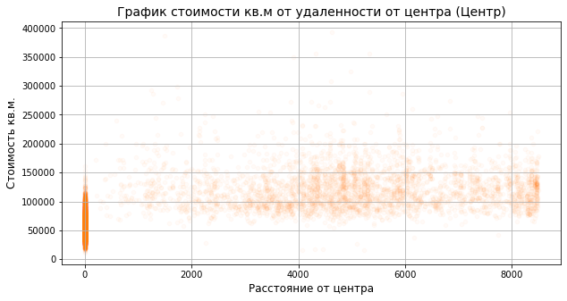

```python
crop_df['city_center_km'] = round(crop_df['city_сenters_nearest'] / 1000)
crop_df['city_center_km'] = crop_df['city_center_km'].astype('int64')

crop_df.sort_values('city_сenters_nearest').plot(
    kind='scatter',
    x='city_сenters_nearest',
    y='price_m2',
    figsize=(10,5),
    grid=True,
    alpha=0.03
)

plt.title('График стоимости кв.м от удаленности от центра (Общая база)', size=14)
plt.xticks(rotation=0)
plt.xlabel('Расстояние от центра', size=12)
plt.ylabel('Стоимость кв.м.', size=12)
plt.show()

crop_df[crop_df['city_center_km'] < 9].sort_values('city_сenters_nearest').plot(
    kind='scatter',
    x='city_сenters_nearest',
    y='price_m2',
    figsize=(10,5),
    grid=True,
    alpha=0.03,
    color='#ff7f0e'

)

plt.title('График стоимости кв.м от удаленности от центра (Центр)', size=14)
plt.xticks(rotation=0)
plt.xlabel('Расстояние от центра', size=12)
plt.ylabel('Стоимость кв.м.', size=12)
plt.show()
```

Нет четкой зависимоти цены квадратного метра жилья и удаленность от центра.

Есть небольшая зависимость чем дальше от центра тем меньше разброс цен.

Коридор сужается с диапазона 50тр.-300тр.за кв.м. в центре, до диапазона 50-125тр.за кв.м. в 50 км от центра.

Посмотрим влияние дня недели на стоимость и на продолжительность продажи:

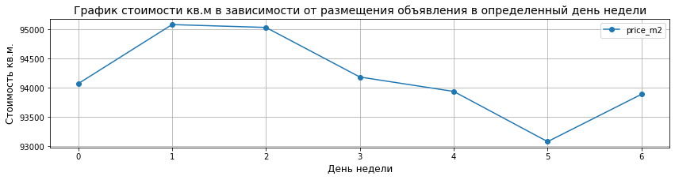

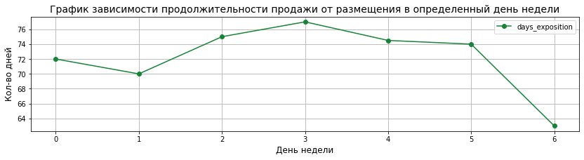

```python
crop_df['weekday'] = crop_df['first_day_exposition'].dt.weekday

(
    crop_df
    .groupby(['weekday'])
    .agg({'price_m2':'median'}).
    plot( y='price_m2', style='o-',  grid=True, figsize=(14, 3))
)

plt.title('График стоимости кв.м в зависимости от размещения объявления в определенный день недели', size=14)
plt.xticks(rotation=0)
plt.xlabel('День недели', size=12)
plt.ylabel('Стоимость кв.м.', size=12)
plt.show()

(
    crop_df
    .groupby(['weekday'])
    .agg({'days_exposition':'median'}).
    plot( y='days_exposition', style='o-',  grid=True, figsize=(14, 3), color='#168337')
)

plt.title('График зависимости продолжительности продажи от размещения в определенный день недели', size=14)
plt.xticks(rotation=0)
plt.xlabel('День недели', size=12)
plt.ylabel('Кол-во дней', size=12)
plt.show()
```

На первом графике видим небольшое увеличение с 94тр. недели вторник и среды до 95тр. и постепенное снижение к концу недели до 93тр. в субботу.

Видимо просмотром объявлений занимаются в начале недели, либо в конце неделе в середине интерес к новым объявлениям снижен. В тоже время средняя цена выше именно при выкладывание объявления в середине недели.

Посмотрим влияние месяца на стоимость и на продолжительность продажи:

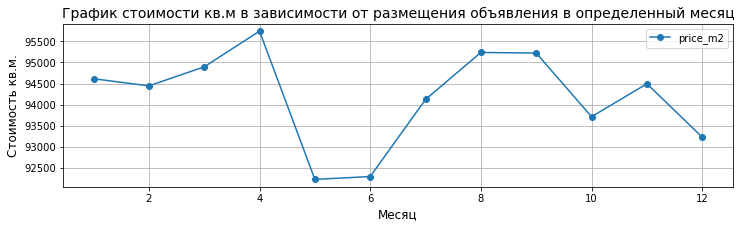

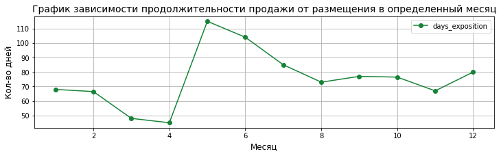

```python
crop_df['month'] = crop_df['first_day_exposition'].dt.month

(
    crop_df
    .groupby(['month'])
    .agg({'price_m2':'median'}).
    plot(
        y='price_m2',
        style='o-',
        grid=True,
        figsize=(12, 3)
    )
)
plt.title('График стоимости кв.м в зависимости от размещения объявления в определенный месяц', size=14)
plt.xticks(rotation=0)
plt.xlabel('Месяц', size=12)
plt.ylabel('Стоимость кв.м.', size=12)
plt.show()


(
    crop_df
    .groupby(['month'])
    .agg({'days_exposition':'median'}).
    plot(
        y='days_exposition',
        style='o-',
        grid=True,
        figsize=(12, 3),
        color='#168337'
    )
)

plt.title('График зависимости продолжительности продажи от размещения в определенный месяц', size=14)
plt.xticks(rotation=0)
plt.xlabel('Месяц', size=12)
plt.ylabel('Кол-во дней', size=12)
plt.show()
```

Цены растут с начала года до апреля, затем май и июнь средняя цена падает к минимуму года (видимо летние отпуска влияют на рынок недвижимости) к августу и сентябрю цена опять растет, затем снижается к концу года.